# 3장R

### 중도절단자료의 경우 최대우도추정

(Maximum Likelihood Estimation for Censored Data)

#### R

- `MASS`와 `fitdistrplus` 패키지의 **`fitdistr` 함수** : 중도절단 고려하지 않음
- `fitdistrplus` 패키지의 **`fitdistcens` 함수** : 중도절단인 경우도 가능

#### Load packages

```r
#install.packages("fitdistrplus")

library(tidyverse)

library(fitdistrplus)
```

#### 생존시간과 중도절단시간 분포

- 생존시간 $\sim Weibull(3,1)$
- 중도절단시간 $\sim Exponential(0.1)$

```r
n <- 200

# parameters of Weibull distribution for survival time
alpha <- 3
lambda <- 1
# parameters of Exponantial distribution for censoring time
rate <- 0.1

wei_exp <- tibble(t= seq(0, 5, length=200),
                ft=dweibull(t,shape=alpha, scale=1/lambda), St=1-pweibull(t,shape=alpha, scale=1/lambda),  ht=ft/St,
                fc=dexp(t, rate), Sc=1-pexp(t, rate), hc=fc/Sc)

head(wei_exp)
```

A tibble: 6 × 7

| t <dbl> | ft <dbl> | St <dbl> | ht <dbl> | fc <dbl> | Sc <dbl> | hc <dbl> |
| --- | --- | --- | --- | --- | --- | --- |
| 0.00000000 | 0.000000000 | 1.0000000 | 0.000000000 | 0.10000000 | 1.0000000 | 0.1 |
| 0.02512563 | 0.001893862 | 0.9999841 | 0.001893892 | 0.09974906 | 0.9974906 | 0.1 |
| 0.05025126 | 0.007574605 | 0.9998731 | 0.007575566 | 0.09949875 | 0.9949875 | 0.1 |
| 0.07537688 | 0.017037726 | 0.9995718 | 0.017045024 | 0.09924906 | 0.9924906 | 0.1 |
| 0.10050251 | 0.030271519 | 0.9989854 | 0.030302265 | 0.09900001 | 0.9900001 | 0.1 |
| 0.12562814 | 0.047253506 | 0.9980192 | 0.047347289 | 0.09875158 | 0.9875158 | 0.1 |

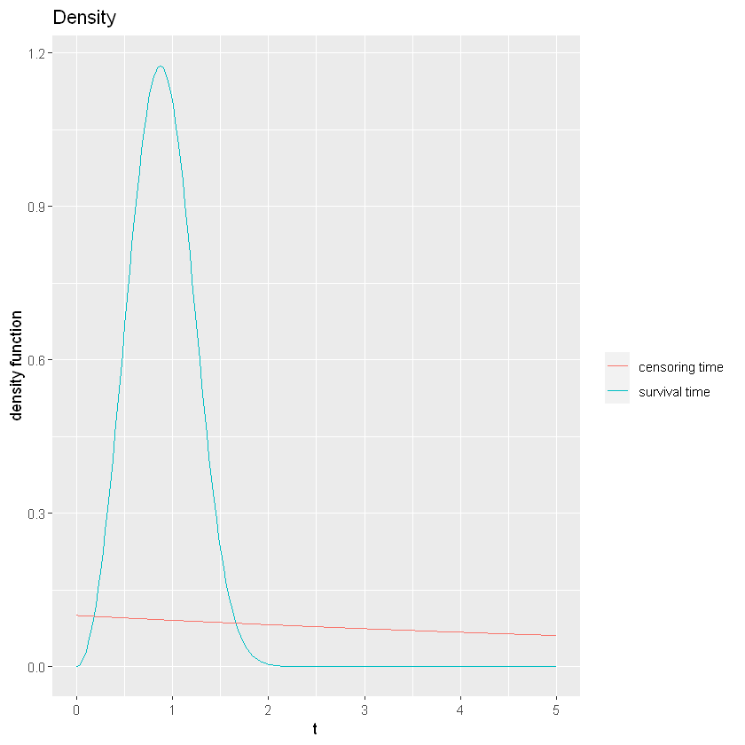

```r
ggplot(wei_exp, aes(x=t))+
    geom_line(aes(y=ft, color="survival time"))+
    geom_line(aes(y=fc, color="censoring time"))+
    xlab("t")+ylab("density function")+
    labs(title="Density", color=" ")
```

#### 자료 생성

```r
set.seed(2003)

stime <- rweibull(n, shape=alpha, scale=1/lambda)
ctime <- rexp(n, rate)

survdata <- tibble(time=ifelse(stime<ctime, stime, ctime),
                   censor=ifelse(stime<ctime, 1, 0))

# write.csv(survdata, 'survdata.csv')

head(survdata)

survdata %>%
       group_by(censor)%>%
       summarize(n=n(), mean=mean(time))
```

A tibble: 6 × 2

| time <dbl> | censor <dbl> |
| --- | --- |
| 0.4334647 | 1 |
| 1.1664504 | 1 |
| 1.1333212 | 1 |
| 1.5099935 | 1 |
| 0.9758378 | 1 |
| 0.4315923 | 1 |

A tibble: 2 × 3

| censor <dbl> | n <int> | mean <dbl> |
| --- | --- | --- |
| 0 | 16 | 0.4449557 |
| 1 | 184 | 0.9008201 |

### R: `fitdistcens` 함수 이용

#### `fitdistcens` 함수에 입력할 자료형태로 변환

- `fitdistcens` 함수는 생존자료가 변수명 `left`와 `right` 형태로 입력되어야 함
  - 구간으로 관측된 자료도 다룰 수 있음
  - 생존시간이 관측된 경우: `left=right`= 관측된 생존시간 값으로 입력
  - 우중도절단시간이 관측된 경우: `left`=NA, `right`= 관측된 중도절단시간 값

```r
fcdata <- survdata %>%
                    mutate(left=ifelse(censor==1, time, NA),
                            right=time)%>%
                    dplyr::select(left,right)
head(fcdata)
```

A tibble: 6 × 2

| left <dbl> | right <dbl> |
| --- | --- |
| 0.4334647 | 0.4334647 |
| 1.1664504 | 1.1664504 |
| 1.1333212 | 1.1333212 |
| 1.5099935 | 1.5099935 |
| 0.9758378 | 0.9758378 |
| 0.4315923 | 0.4315923 |

#### 모수적 생존함수 추정

```r
fcdata <- as.data.frame(fcdata)
(fit <- fitdistcens(fcdata, "weibull"))

#ls(fit)
alphahat <- fit$estimate[1]
lambdahat <- 1/fit$estimate[2]
#fit$sd
```

```
Fitting of the distribution ' weibull ' on censored data by maximum likelihood
Parameters:
       estimate
shape 2.4994346
scale 0.9572057
```

- **모형**: 생존시간 분포 $\sim Weibull(\alpha,\lambda)$
- **모수의 최대우도 추정**:
  - $\hat{\alpha}=2.50,\ \hat{\lambda}=1/0.96=1.05$
  - 95% 신뢰구간

$\Rightarrow$

```r
fit$sd
```

**shape**

0.146914589971946

**scale**

0.0284880667178719

```r
fit$estimate[1]-1.96*fit$sd[1]

fit$estimate[1]+1.96*fit$sd[1]
```

**shape:** 2.21148198858102

**shape:** 2.78738718127104

- **추정된 생존함수** : $\hat{S}(t)=\exp[-(\hat{\lambda} t)^{\hat{\alpha}}]=\exp[-(1.05t)^{2.5}]$
- **추정된 위험함수** : $\hat{h}(t)=\hat{\alpha}\hat{\lambda}(\hat{\lambda} t)^{\hat{\alpha}-1}= 2.63(1.05t)^{1.5}$

**그래프** : $h(t)$와 $\hat{h}(t)$

```r
h_ml <- tibble(t= seq(0, 5, length=100),
                 ht=alpha*lambda*(lambda*t)^(alpha-1),
                 hatht=alphahat*lambdahat*(lambdahat*t)^(alphahat-1))
```

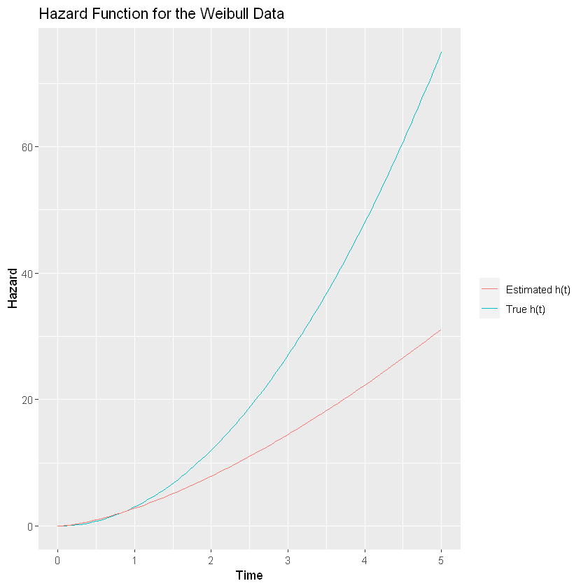

```r
ggplot(h_ml, aes(x=t))+
    geom_line(aes(y=ht, color="True h(t)"))+
    geom_line(aes(y=hatht, color="Estimated h(t)"))+
    xlab("Time")+ylab("Hazard")+
    labs(title="Hazard Function for the Weibull Data", color=" ")
```

#### 참고: 중도절단이 없는 경우

```r
wdata <- data.frame(left=stime,right=stime)
fitdistcens(wdata, "weibull")
```

```
Fitting of the distribution ' weibull ' on censored data by maximum likelihood
Parameters:
      estimate
shape 3.026504
scale 1.013041
```

```r
wdata <- data.frame(left=stime,right=stime)
fitdistcens(wdata, "weibull")
```

```
Fitting of the distribution ' weibull ' on censored data by maximum likelihood
Parameters:
      estimate
shape 3.026504
scale 1.013041
```

### 과제

1장 서론 과제로 각자 사용하였던 자료를 이용하여 생존함수의 분포를 다음 두가지 경우로 가정하고 생존함수를 추정하시오

1. 지수분포
2. 와이블분포